# EDA buscas

O objeto principal da análise são as buscas e a navegação depois da busca. Criamos esses dados a partir dos dados originais da wikimedia em `/data/search_data.csv`.

Aqui, exploramos esses dados.

```r
library(tidyverse)
library(here)
library(lubridate)
theme_set(theme_bw())
```

```r
buscas = read_csv(here::here("data/search_data.csv"))
```

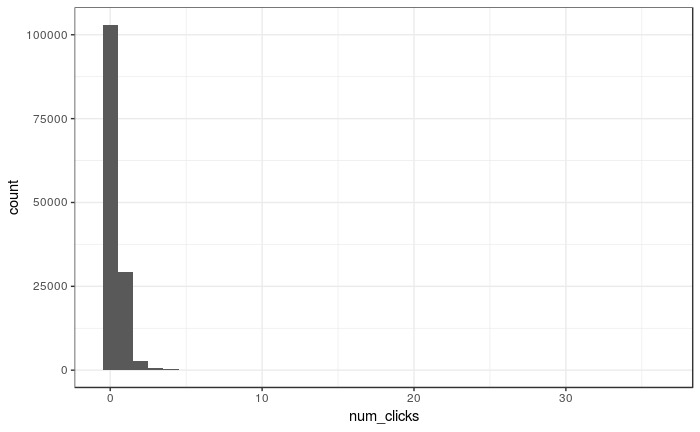

```r
buscas %>%
    ggplot(aes(x = num_clicks)) +
    geom_histogram(binwidth = 1)
```

Removendo hora e minuto da data para identificar apenas o dia.

```r
buscas$session_start_date <- buscas$session_start_date %>% as.Date("%d/%m/%Y")
```

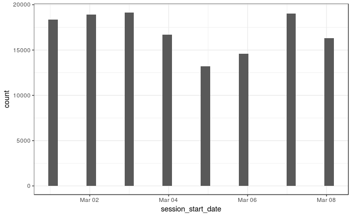

```r
buscas %>% ggplot(aes(x=session_start_date)) +
    geom_histogram()
```

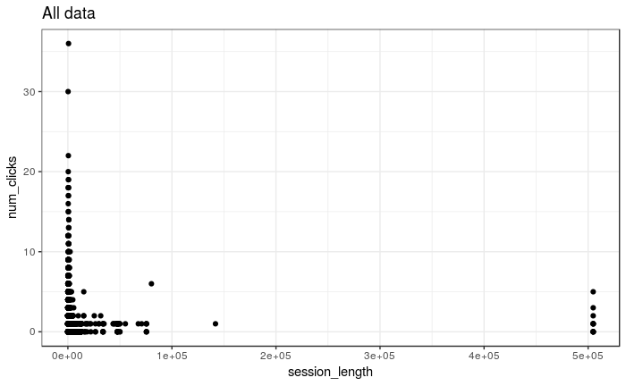

```r
buscas %>%  ggplot(aes(x=session_length, y=num_clicks))+
    geom_point()+
    labs(title = "All data")
```

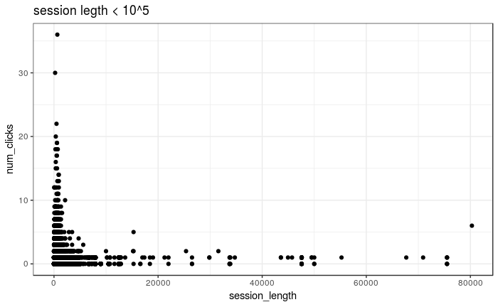

```r
buscas %>% filter(session_length <= 100000) %>%  ggplot(aes(x=session_length, y=num_clicks))+
    geom_point()+
    labs(title = "session legth < 10^5")
```

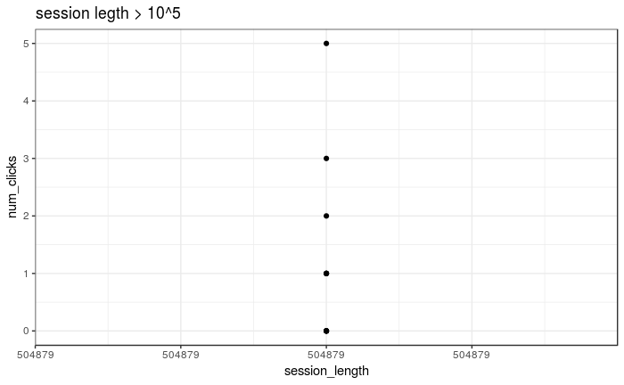

```r
buscas %>% filter(session_length >= 500000) %>%  ggplot(aes(x=session_length, y=num_clicks))+
    geom_point()+
    labs(title = "session legth > 10^5")
```

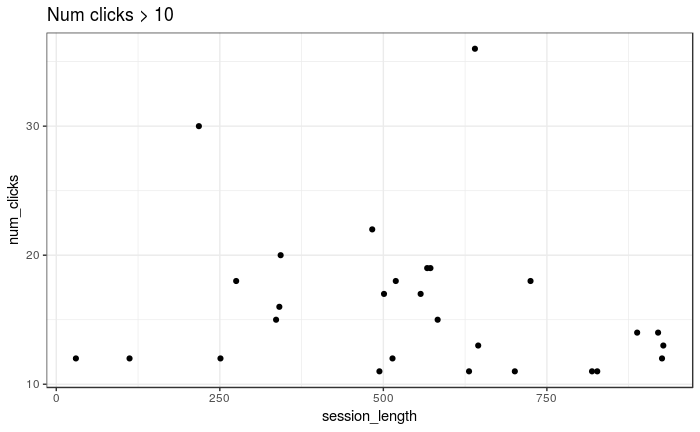

```r
buscas %>% filter(num_clicks > 10) %>%  ggplot(aes(x=session_length, y=num_clicks))+
    geom_point()+
    labs(title = "Num clicks > 10")
```

```r
buscas %>% filter(num_clicks == 0) %>% summarise(qtd=n()) / buscas %>% filter(num_clicks >= 0) %>% summarise(qtd=n())
```

| qtd |
| --- |
| 0.7563237 |

o ponto num clicks = 30 parece estranho, pois foram 30 páginas visitadas em 4 min.

75% das pesquisas não tiveram clicks em nenhum dos seus resultados.

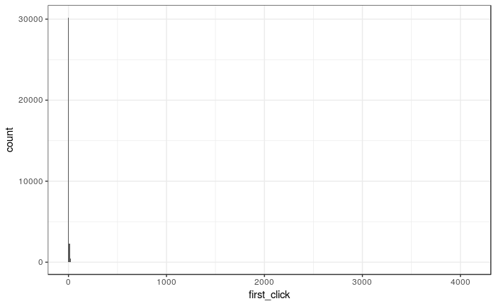

```r
buscas %>% filter(first_click != "NA") %>% ggplot(aes(x=first_click))+
    geom_histogram(binwidth = 10)
```

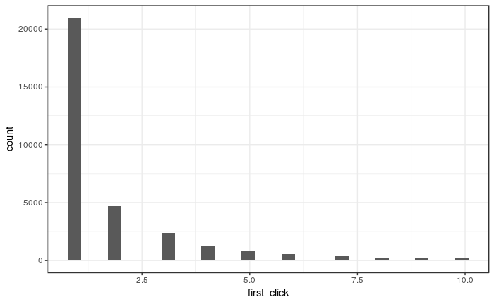

```r
buscas %>% filter(first_click >= 0 & first_click <= 10) %>%
    ggplot(aes(x=first_click))+
    geom_histogram()
```

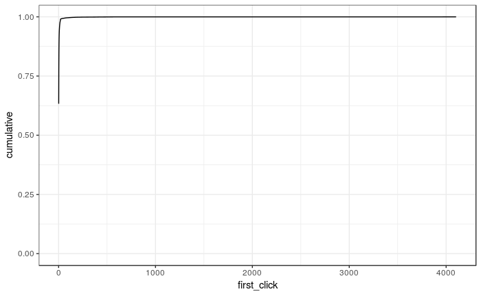

```r
cdf <- buscas %>% filter(first_click != "NA") %>% group_by(first_click) %>% summarise(qtd = n()) %>%
    mutate(cumulative=cumsum(qtd)/sum(qtd))
cdf %>%
    ggplot(aes(x=first_click,y=cumulative))+
    geom_line()+
    scale_y_continuous(limits=c(0, 1))
```

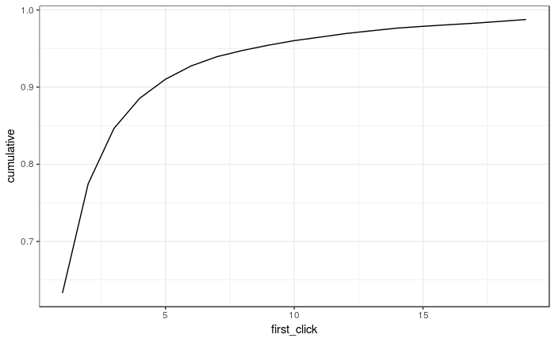

```r
cdf %>% filter(cumulative <= 0.99) %>%
    ggplot(aes(x=first_click,y=cumulative))+
    geom_line()
```

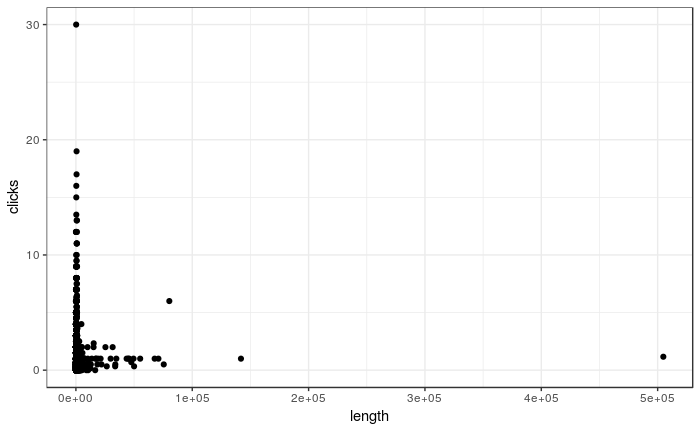

```r
sumario <- buscas %>% group_by(session_id) %>% summarise(length = mean(session_length), clicks = mean(num_clicks))
sumario %>% filter(length > 0) %>%
    ggplot(aes(x=length, y=clicks))+
    geom_point()
```

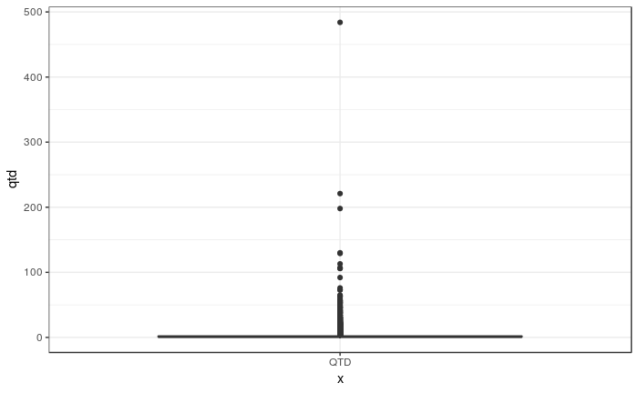

```r
buscas %>% group_by(session_id) %>% summarise(qtd=n()) %>%
    ggplot(aes(x="QTD", y=qtd))+
    geom_boxplot()
```

1-What is our daily overall clickthrough rate? How does it vary between the groups?

[figure not shown]

```r
buscas %>% filter(!is.na(num_clicks)) %>%
    group_by(group) %>%
    summarise(mean=median(num_clicks)) %>%
    ggplot(aes(x=group,y=mean))+
    geom_bar(stat = "identity")
```

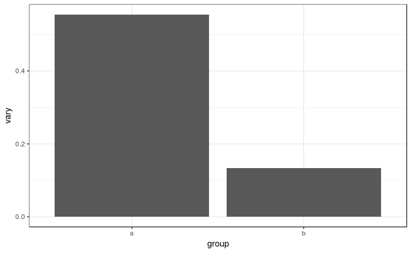

```r
buscas %>% filter(!is.na(num_clicks)) %>%
    group_by(group) %>%
    summarise(vary=var(num_clicks)) %>%
    ggplot(aes(x=group,y=vary))+
    geom_bar(stat = "identity")
```

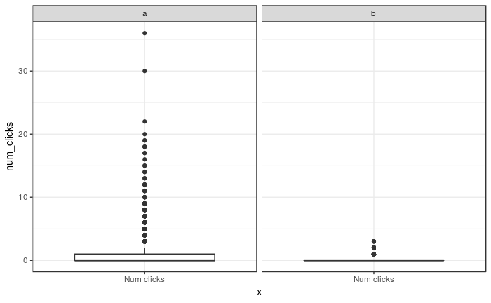

```r
buscas %>% filter(num_clicks != "NA") %>%
    group_by(session_start_date) %>%
    ggplot(aes(x="Num clicks", y=num_clicks))+
    geom_boxplot()+
    facet_wrap(~group)
```

A maioria das buscas, em ambos os grupos, não possuem clicks, porém o grupo ‘a’ possui um range bem maior do que o grupo ‘b’.

2-Which results do people tend to try first? How does it change day-to-day?

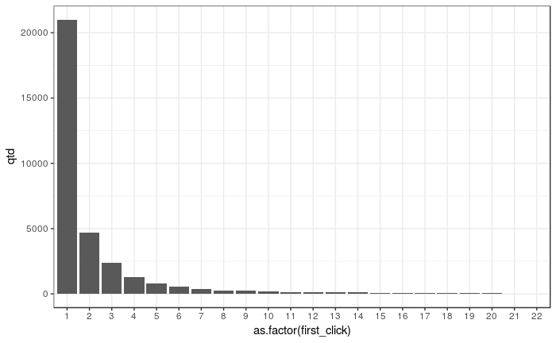

```r
buscas %>% filter(first_click != "NA") %>%
    group_by(first_click) %>%
    summarise(qtd=n()) %>%
    filter(qtd >= 10) %>%
    ggplot(aes(x=as.factor(first_click),y=qtd))+
    geom_bar(stat = "identity")
```

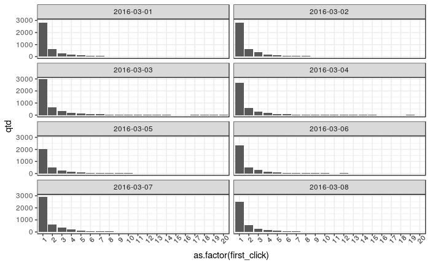

```r
buscas %>% filter(first_click != "NA") %>%
    group_by(first_click, session_start_date) %>%
    summarise(qtd=n()) %>%
    filter(qtd >= 10) %>%
    ggplot(aes(x=as.factor(first_click),y=qtd))+
    geom_bar(stat = "identity")+
    theme(axis.text.x = element_text(angle = 45))+
    facet_wrap(~session_start_date, ncol = 2)
```

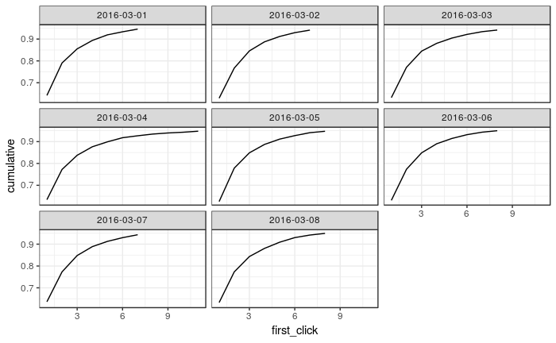

```r
cdf_Date <- buscas %>% filter(first_click != "NA") %>% group_by(session_start_date, first_click) %>% summarise(qtd = n()) %>%
    mutate(cumulative=cumsum(qtd)/sum(qtd))
cdf_Date %>%
    filter(cumulative <= 0.95) %>%
    ggplot(aes(x=first_click,y=cumulative))+
    geom_line()+
    #scale_y_continuous(limits=c(0, 1))+
    facet_wrap(~session_start_date)
```

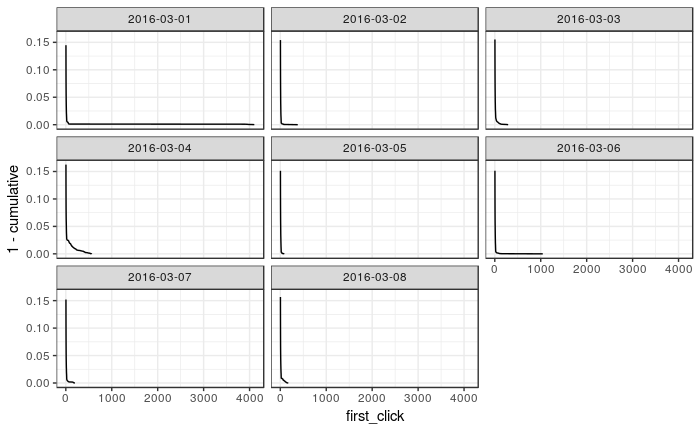

```r
cdf_Date %>%
    filter(first_click >= 3) %>%
    ggplot(aes(x=first_click,y=1-cumulative))+
    geom_line()+
    #scale_y_continuous(limits=c(0, 1))+
    facet_wrap(~session_start_date)
```

3-What is our daily overall zero results rate? How does it vary between the groups?

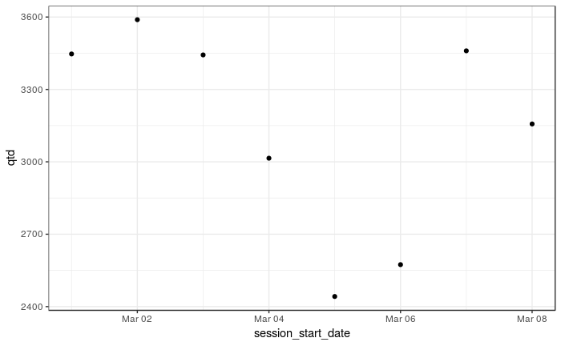

```r
buscas %>% filter(results == 0) %>%
    group_by(session_start_date) %>%
    summarise(qtd=n()) %>%
    ggplot(aes(x=session_start_date, y =qtd))+
    geom_point()
```

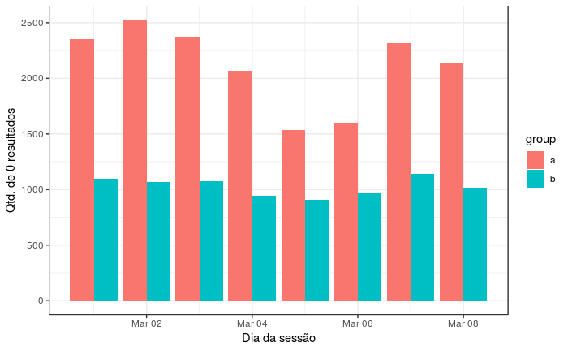

```r
buscas %>% filter(results == 0) %>%
    group_by(session_start_date, group) %>%
    summarise(qtd=n()) %>%
    ggplot(aes(x=session_start_date, y=qtd, fill=group))+
    geom_bar(stat = "identity", position = "dodge")+
    labs(x="Dia da sessão", y="Qtd. de 0 resultados")
```

É possível observar que o grupo ‘a’ possui uma variação maior que o grupo ‘b’, bem como uma participação maior na quantidade total de zero resultados.

4-Let session length be approximately the time between the first event and the last event in a session. Choose a variable from the dataset and describe its relationship to session length. Visualize the relationship.

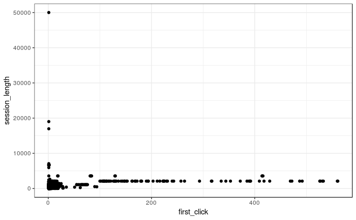

```r
buscas %>% filter(session_length < 100000 & group=="a" & session_start_date=="2016-03-04" & first_click>=1) %>%
    ggplot(aes(y=session_length,x=first_click))+
    geom_point()
```

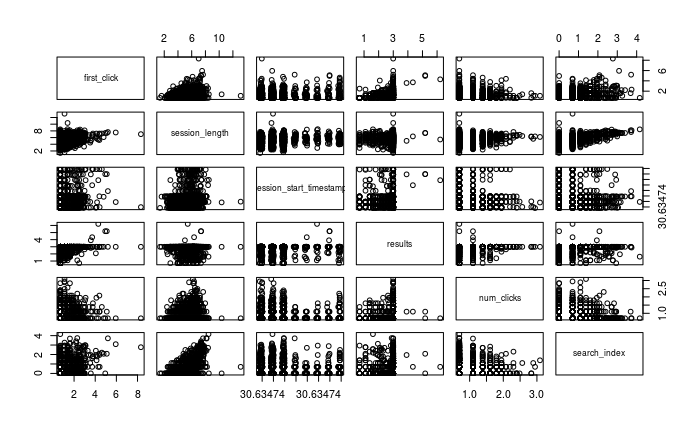

```r
buscas %>% select(first_click,session_length,session_start_timestamp,results,num_clicks, search_index) %>%
    log() %>%
    filter(first_click > 0 & num_clicks > 0) %>%
    pairs()
```

```r
buscas %>% select(first_click,session_length,session_start_timestamp,results,num_clicks,search_index) %>%
    filter(first_click > 0 & num_clicks > 0) %>%
    log() %>%
    cor(method = "spearman")
```

```
                        first_click session_length session_start_timestamp      results   num_clicks search_index
first_click             1.000000000    0.088569114             0.001386921  0.094678523  0.003052345  0.088580818
session_length          0.088569114    1.000000000            -0.073460436  0.001084453  0.070438291  0.430115581
session_start_timestamp 0.001386921   -0.073460436             1.000000000 -0.006682604 -0.344191018 -0.004159459
results                 0.094678523    0.001084453            -0.006682604  1.000000000  0.044453407  0.010324088
num_clicks              0.003052345    0.070438291            -0.344191018  0.044453407  1.000000000 -0.025581800
search_index            0.088580818    0.430115581            -0.004159459  0.010324088 -0.025581800  1.000000000
```

```r
teste[is.na(teste$search_length) & teste$search_index == 1,"search_length"] <- teste[is.na(teste$search_length), "session_length"]
```

[output not shown]